# Behind Bars in Illinois: A Comprehensive Analysis of State Prison Data

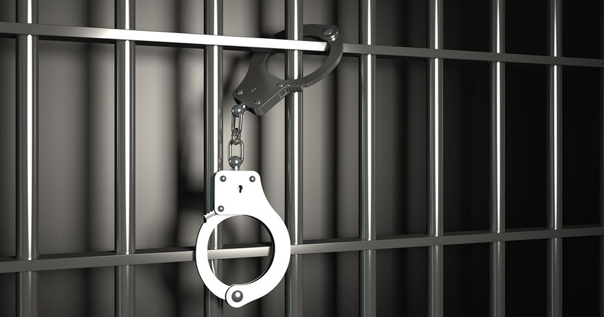

## Introduction

By harnessing the power of data, this project paints a comprehensive picture of the Illinois prison system. I dive into inmate demographics, sentencing structures, lengths of stay, and the intricate interplay of various factors affecting the incarcerated population. As I sift through the numbers, I unearth nuanced stories that challenge conventional narratives and provoke critical discussions around justice and reform.

Peering beyond cell bars and legal codes, this endeavor aspires to ignite meaningful conversations about the dynamics of imprisonment in Illinois. Join me as I navigate through the data to reveal a deeper understanding of incarceration in Illinois.

## Table of Content

- Data Importation and Reading
- Data Cleaning/Wrangling
- Data Exploration
- Demographic and Personal Information
  - Age at Arrest
  - Marital Status
  - Employment Status
  - Race
  - Sex
  - Education Status
- Incarceration Details:
  - Days in Jail
  - Prisoner Type
  - Offense Level
  - Incarceration Reason
  - Release Reason

## Data Importation and Reading

```python
import numpy as np
import pandas as pd
import matplotlib.pyplot as plt
import seaborn as sns
sns.set_style('darkgrid')
%matplotlib inline
```

```python
# Read CSV file with specified data types

dtype_options = {'zip_code': str}
jail_record = pd.read_csv('data/jail-booking-data-1.csv', dtype=dtype_options)
```

```python
jail_record.head(3)
```

|  | booking_number | booking_date | booking_time | jacket_number | jacket_type | released_date | released_time | arrest_agency | age_at_arrest | age_at_release | ... | crime | superhighlevel | finalanswercode | finalanswerdesc | custody_class | inmate_status | incarc_reason | booking_reason | release_reason_description | release_reason |
| --- | --- | --- | --- | --- | --- | --- | --- | --- | --- | --- | --- | --- | --- | --- | --- | --- | --- | --- | --- | --- | --- |
| 0 | 201200000001 | 1/1/2012 | 0:19:14 | 22914 | A | 1/1/2012 | 1:57:29 | Champaign Police Department | 51.0 | 51.0 | ... | DRIVING UNDER THE INFLUENCE OF ALCOHOL | DUI | C69 | Driving Under the Influence | NaN | NaN | Arrest - Without Warrant | Arrested Without Warrant | Credit Card Bond Posted | Bond Posted |
| 1 | 201200000001 | 1/1/2012 | 0:19:14 | 22914 | A | 1/1/2012 | 1:57:29 | Champaign Police Department | 51.0 | 51.0 | ... | OTHER TRAFFIC OFFENSES | Traffic | C28 | Traffic Offenses | NaN | NaN | Arrest - Without Warrant | Arrested Without Warrant | Credit Card Bond Posted | Bond Posted |
| 2 | 201200000001 | 1/1/2012 | 0:19:14 | 22914 | A | 1/1/2012 | 1:57:29 | Champaign Police Department | 51.0 | 51.0 | ... | RESISTING,OBSTRUCTING,OR DISARMING A POLICE OFC | Public Order | C31 | Interfering w/Public Officers | NaN | NaN | Arrest - Without Warrant | Arrested Without Warrant | Credit Card Bond Posted | Bond Posted |

3 rows × 38 columns

## Data Cleaning/Wrangling

```python
# Dropping Columns
columns_to_drop = ['booking_number','jacket_number']
jail_record=jail_record.drop(columns_to_drop,axis=1)
```

```python
# Changing to Datetime
jail_record['booking_date'] = pd.to_datetime(jail_record['booking_date'])
jail_record['released_date'] = pd.to_datetime(jail_record['released_date'])
```

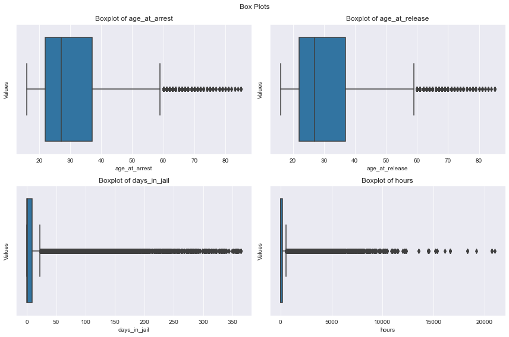

```python
# Using boxplot to look for outliers

plt.figure(figsize=(12, 8))
plt.suptitle('Box Plots')  # Adding a common title for the entire set of subplots

plt.subplot(2, 2, 1)
sns.boxplot(x=jail_record['age_at_arrest'])
plt.xlabel('age_at_arrest')
plt.ylabel('Values')
plt.title('Boxplot of age_at_arrest')

plt.subplot(2, 2, 2)
sns.boxplot(x=jail_record['age_at_release'])
plt.xlabel('age_at_release')
plt.ylabel('Values')
plt.title('Boxplot of age_at_release')

plt.subplot(2, 2, 3)
sns.boxplot(x=jail_record['days_in_jail'])
plt.xlabel('days_in_jail')
plt.ylabel('Values')
plt.title('Boxplot of days_in_jail')

plt.subplot(2, 2, 4)
sns.boxplot(x=jail_record['hours'])
plt.xlabel('hours')
plt.ylabel('Values')
plt.title('Boxplot of hours')

plt.tight_layout()  # Adjusts spacing between subplots for better layout
plt.show()
```

After cleaning, the number of rows and columns of the dataset is 67923 and 36 respectively.

## Data Exploration

```python
# To get dataset information
jail_record.info()
```

```
<class 'pandas.core.frame.DataFrame'>
RangeIndex: 67923 entries, 0 to 67922
Data columns (total 36 columns):
 #   Column                      Non-Null Count  Dtype
---  ------                      --------------  -----
 0   booking_date                67923 non-null  datetime64[ns]
 1   booking_time                67923 non-null  object
 2   jacket_type                 67923 non-null  object
 3   released_date               67923 non-null  datetime64[ns]
 4   released_time               67923 non-null  object
 5   arrest_agency               67038 non-null  object
 6   age_at_arrest               67461 non-null  float64
 7   age_at_release              67461 non-null  float64
 8   days_in_jail                67923 non-null  int64
 9   hours                       67923 non-null  int64
```

[output cut: 28 more lines]

```python
# Geting dataset description
jail_record.describe()
```

|  | age_at_arrest | age_at_release | days_in_jail | hours |
| --- | --- | --- | --- | --- |
| count | 67461.000000 | 67461.000000 | 67923.000000 | 67923.000000 |
| mean | 30.776686 | 30.822623 | 15.819899 | 397.704651 |
| std | 11.142150 | 11.145976 | 38.217117 | 1043.151700 |
| min | 16.000000 | 16.000000 | 0.000000 | 0.000000 |
| 25% | 22.000000 | 22.000000 | 0.000000 | 3.000000 |
| 50% | 27.000000 | 27.000000 | 1.000000 | 20.000000 |
| 75% | 37.000000 | 37.000000 | 9.000000 | 215.000000 |
| max | 85.000000 | 85.000000 | 364.000000 | 20983.000000 |

#### SImple Exploratory Bivariate Analysis

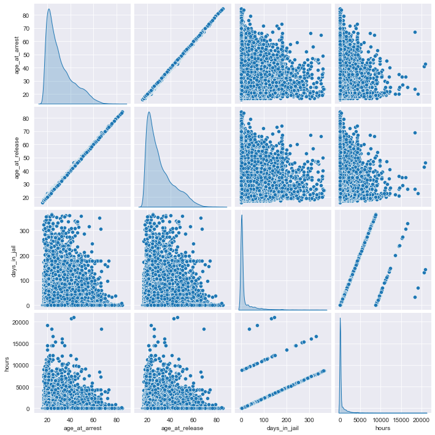

```python
sns.pairplot(jail_record, diag_kind='kde')
plt.show()
```

Upon analyzing the pairplot of the dataset, it becomes evident that there is a lack of significant relationships between most variables. However, an anticipated and normal pattern emerges when examining the relationship between 'age_at_arrest' and 'age_at_release.' The scatter plots for these two variables exhibit a distinct linear trend, reflecting the expected outcome where individuals are typically released at an age similar to when they were initially arrested. This observation aligns with common understanding and is consistent with the functioning of the legal and correctional systems.

## Age At Arrest

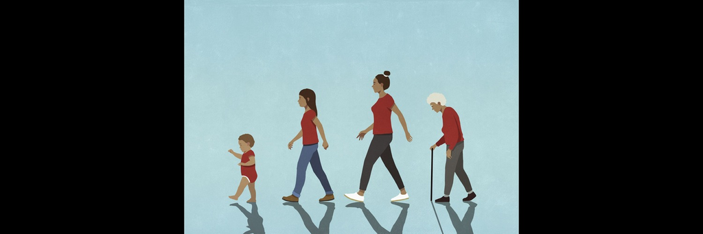

In the context of Illinois prison data, investigating the ages at which individuals face arrest offers a window into the dynamics of the justice system. By examining the distribution of arrest ages, I can uncover significant insights and patterns. Age at arrest not only provides a snapshot of when individuals come into contact with the legal system but also opens doors to examining disparities, the evolution of behavior across different age groups, and the subsequent paths individuals traverse. This analysis aims to illuminate correlations between age and legal interactions, providing valuable context for discussions about the effectiveness and equity of Illinois' legal processes.

```python
age= jail_record.age_at_arrest.value_counts().sort_index().head(60)
age.index = age.index.astype(int)
```

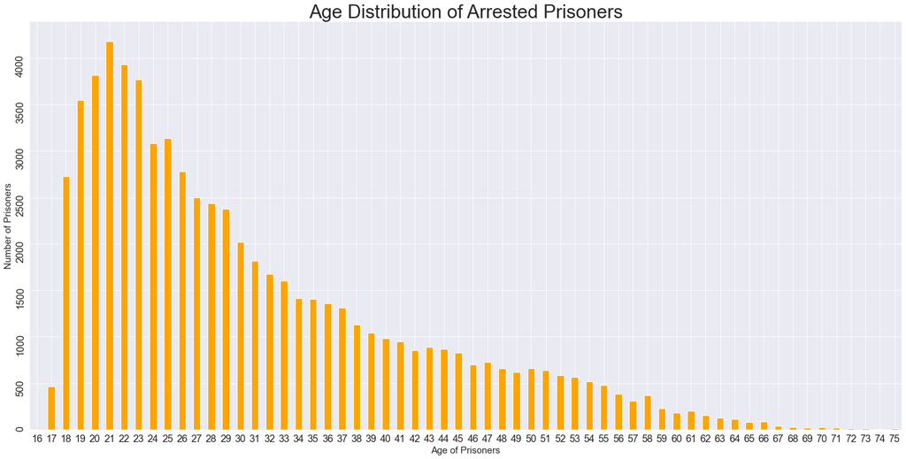

```python
age.plot(kind='bar',figsize=(25,12),color='orange')

plt.xticks(fontsize=16, rotation=360)
plt.yticks(fontsize=16, rotation=90)

plt.xlabel('Age of Prisoners',fontsize=15)
plt.ylabel('Number of Prisoners',fontsize=15)
plt.title("Age Distribution of Arrested Prisoners"
          ,fontsize=30)
```

### Questions

- **Why does the age distribution of arrested prisoners show a peak in the twenties?**

> **Transition to Adulthood:** Young adults in their early twenties often experience significant life transitions, such as leaving home for higher education or work. These transitions might expose them to new environments and peer influences, potentially leading to risky behaviors.

> **Exploration and Identity:** This age range is characterized by exploration and identity formation. Some individuals might engage in riskier activities as they seek to define themselves and their place in society.

> **Peer Pressure:** Peer interactions and influences can play a pivotal role in criminal behavior. The twenties mark a phase where individuals are more susceptible to peer pressure, potentially leading to involvement in unlawful activities.

> **Impulsivity:** Research suggests that the prefrontal cortex, responsible for impulse control, fully develops only by the mid-twenties. This could contribute to riskier decision-making among young adults.
- **Why is there a noticeable decrease in the age distribution from the age of 26 and downwards, as evident from the provided data on age distribution?**

> **Age-Related Responsibilities:** As individuals approach their late twenties, increased responsibilities such as work, education, and family life might lead to reduced engagement in activities that lead to arrests.

> **Maturation and Risk Aversion:** Maturity could contribute to a wiser approach to legal interactions. For instance, individuals might become more cautious about avoiding risky behaviors to prevent legal consequences.

> **Behavioral Adjustments:** Legal interventions and personal growth could lead to behavioral adjustments. For example, completing educational programs within correctional facilities might influence future conduct and legal involvement.

> **Legal Consequences:** Early encounters with the criminal justice system might serve as a deterrent, leading to heightened awareness of legal consequences and decreased involvement in unlawful behavior.
- **How does the observed age distribution reflect changes in behavior as individuals move across various age groups, and what insights can be drawn from this trend?**

The age distribution data indicates a peak in arrests during early twenties, gradually declining with increasing age. This suggests that legal interactions are more frequent among young adults, possibly due to various factors like risk-taking behaviors. As individuals age, decreased arrest frequencies imply a maturing influence on behavior and decision-making. By studying this trend along with other factors, we can discover how behaviors vary with age. This helps us talk about ways to create specific plans for different age groups in prison.

## Marital Status

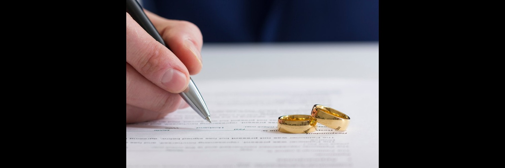

Examining the connection between marital status and interactions with the criminal justice system in Illinois offers insights into how personal life circumstances intersect with legal pathways. By exploring the distribution of different marital statuses among those within the dataset, I aim to uncover patterns that shed light on potential correlations between marital status and legal encounters. This analysis provides a window into the complex dynamics of the justice system, contributing to a broader understanding of how **individual backgrounds** may influence the criminal justice experience.

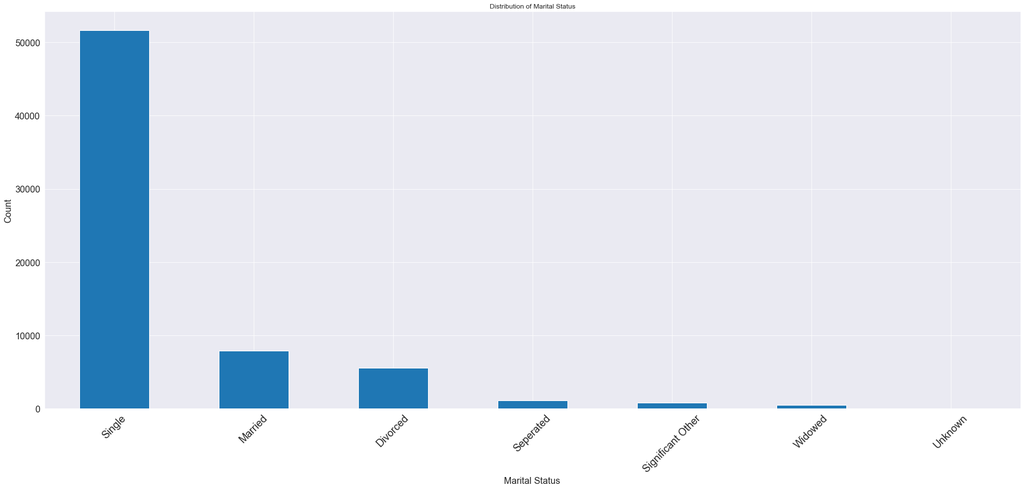

```python
marital= jail_record.maritial_status.value_counts()
plt.figure(figsize=(25,12))
marital.plot(kind='bar')

plt.xlabel('Marital Status',fontsize=16)
plt.ylabel('Count',fontsize=16)
plt.title('Distribution of Marital Status')

plt.xticks(fontsize=18,rotation=45)# Rotate x-labels for better visibility
plt.yticks(fontsize=16)
plt.tight_layout()
plt.show()
```

### Observations

- **Dominant Marital Status:** The most frequent marital status among individuals in this dataset is "Single," with a significantly higher count compared to other statuses. This suggests that a substantial portion of individuals arrested have not been married.
- **Variety of Marital Statuses:** The data reveals a range of marital statuses beyond "Single." This diversity includes "Married," "Divorced," "Separated," "Significant Other," "Widowed," and "Unknown."
- **Marital Diversity:** While "Single" is the most common marital status, a non-negligible number of individuals have other marital statuses. This diversity underscores the relevance of considering marital status as a potential factor influencing legal interactions.
- **Complex Lives:** The presence of "Divorced," "Separated," and "Widowed" statuses indicates that individuals with various marital experiences interact with the legal system. This suggests that the criminal justice system's impact is not limited to just single individuals

### Questions

- **What factors contribute to the higher prevalence of the "Single" marital status among prisoners in Illinois State?**

The predominance of the "Single" marital status among arrested individuals might be influenced by a combination of factors, including age demographics and potential correlations between **being single and criminal rates.** Here's how these factors could be interconnected:

> 1. **Age Demographics:** The high prevalence of "Single" status could be related to the age distribution of arrested individuals. The dataset showed a peak in arrests around the early twenties. Young adults in this age group might be more likely to be single as they are still in the process of forming long-term relationships or getting married.
> 2. **Age and Risk-Taking:** Young adults often engage in risk-taking behaviors due to factors like peer influence, seeking independence, and exploring new experiences. These behaviors can sometimes lead to legal interactions. The link between being in the early twenties (when many are single) and heightened risk-taking might contribute to the higher representation of "Single" individuals in the arrested population.
> 3. **Social Support:** Being in a committed relationship or married might provide individuals with a support system that helps deter engagement in risky or criminal activities. Single individuals might have different support networks, potentially affecting their decision-making and behavior.
> 4. **Societal Factors:** Societal norms and expectations around marriage and family might influence the relationship between marital status and criminal involvement. Single individuals might face different economic, social, and psychological pressures that could contribute to their interactions with the legal system.

While the predominance of the "Single" marital status could be influenced by age-related behaviors and societal dynamics, it's essential to conduct further analysis to establish any causal relationships. Exploring additional variables and conducting statistical analyses might provide a clearer understanding of how being single intersects with criminal rates and legal interactions.

- **Can the institution of marriage contribute to reducing crime rates?**

Marriage is often associated with a range of social and economic benefits that can potentially contribute to lower involvement in criminal activities. While the relationship between marriage and crime rates can be complex and influenced by various factors, several reasons suggest that marriage might help curb crime rates:

> 1. **Stability and Support:** Marriage can provide individuals with emotional and psychological stability, as well as a support system in the form of a spouse and family. This support network can deter engagement in risky behaviors that might lead to criminal activities.
> 2. **Responsibility:** Marriage often comes with increased responsibilities, such as taking care of a partner and potential children. These responsibilities can motivate individuals to make better life choices, as they have others depending on them.
> 3. **Social Integration:** Being part of a married couple can enhance social integration and community ties. Strong community connections can promote a sense of belonging and reduce the likelihood of engaging in criminal activities.
> 4. **Economic Stability:** Marriage can contribute to economic stability through shared financial resources and joint decision-making. Economic stability can reduce the financial pressures that sometimes drive individuals to commit crimes.
> 5. **Future Orientation:** Marriage is often associated with planning for the future, such as raising a family and building a life together. This forward-looking perspective can discourage individuals from participating in criminal activities that might jeopardize these plans.
> 6. **Legal and Social Consequences:** The prospect of legal and social consequences affecting not only the individual but also their spouse and family can act as a deterrent against criminal behavior.
> 7. **Positive Role Models:** Marriage can provide positive role models within the family structure, shaping behavior and values for both parents and children.

However, it's important to note that the relationship between marriage and crime rates is not universally linear or deterministic. Individual circumstances, cultural contexts, and societal factors play crucial roles in shaping this relationship. Moreover, while marriage might be a factor, it is not the sole determinant of criminal behavior. A comprehensive approach to reducing crime rates involves addressing multiple social, economic, and systemic factors that contribute to criminal activities in different communities.

## Employment Status

[figure not shown]

**Introduction to Employment Status Analysis:**

In this section, I delve into the employment status of individuals at the time of their arrest. Understanding the employment landscape during the moments leading to legal interactions provides valuable insights into the dynamics between individuals and the criminal justice system. By examining the diverse employment statuses, I aim to uncover connections between employment circumstances and legal interactions, shedding light on how employment influences the experiences of individuals within the criminal justice system.

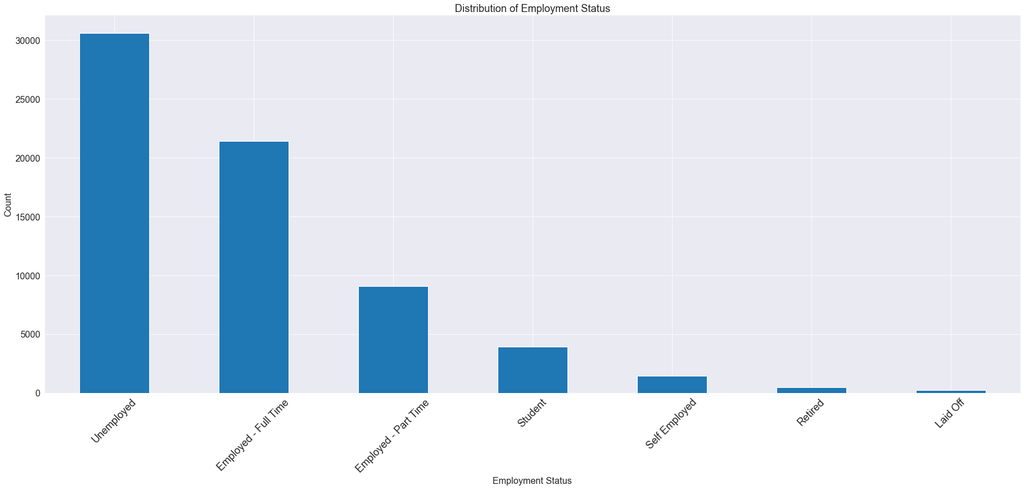

```python
employment= jail_record.employment_status.value_counts()
plt.figure(figsize=(25,12))
employment.plot(kind='bar')

plt.xlabel('Employment Status',fontsize=16)
plt.ylabel('Count',fontsize=16)
plt.title('Distribution of Employment Status',fontsize=18)

plt.xticks(fontsize=18,rotation=45)# Rotate x-labels for better visibility
plt.yticks(fontsize=16)
plt.tight_layout()
plt.show()
```

### Observations

- **Predominantly Unemployed:** The most frequent employment status among individuals in the dataset is "Unemployed." This suggests that a significant portion of individuals arrested are not currently employed.
- **Variety of Employment Statuses:** The dataset reflects a range of employment statuses beyond just "Unemployed." This diversity includes "Employed - Full Time," "Employed - Part Time," "Student," "Self Employed," "Retired," and "Laid Off."
- **Underemployment:** The presence of "Employed - Part Time" suggests that some individuals arrested are employed but only on a part-time basis. This indicates a segment of the population who may be experiencing underemployment.

### Question

The predominance of unemployment among incarcerated individuals suggests a potential relationship between unemployment and criminal involvement. While the relationship is complex and influenced by various factors, the higher count of "Unemployed" individuals could indicate that there might be a correlation between joblessness and criminal activities. Here are a few points to consider:

> 1. **Economic Pressures:** Unemployment can lead to financial stress and economic difficulties, which might increase the likelihood of individuals resorting to illegal activities to meet their needs.
> 2. **Lack of Structure:** Employment provides a daily routine and purpose. The absence of stable employment might leave individuals with more free time and less structure, increasing the chances of engaging in criminal behaviors.
> 3. **Psychosocial Impact:** Joblessness can lead to feelings of frustration, hopelessness, and low self-esteem, factors that might contribute to criminal activities.
> 4. **Social Networks:** Employment often involves social interactions and connections. Unemployment might isolate individuals from positive social networks, making them more susceptible to negative influences.
> 5. **Causal Relationship:** While unemployment could lead to crime, it's important to consider that criminal records might also hinder employment opportunities, creating a potential cycle of joblessness and criminal involvement.
> 6. **Other Factors:** It's important to recognize that while unemployment can be a contributing factor, criminal behavior is influenced by a multitude of socioeconomic, cultural, and personal factors.
> 7. **Context Matters:** The relationship between unemployment and crime can vary based on local economic conditions, access to social services, law enforcement practices, and other contextual factors.

While the data suggests a correlation, determining causality and the strength of the relationship requires more comprehensive research and analysis. Addressing unemployment's potential role in criminal involvement involves a holistic approach that considers various interventions, including vocational training, job placement services, and economic support to help individuals transition away from criminal activities.

## Race

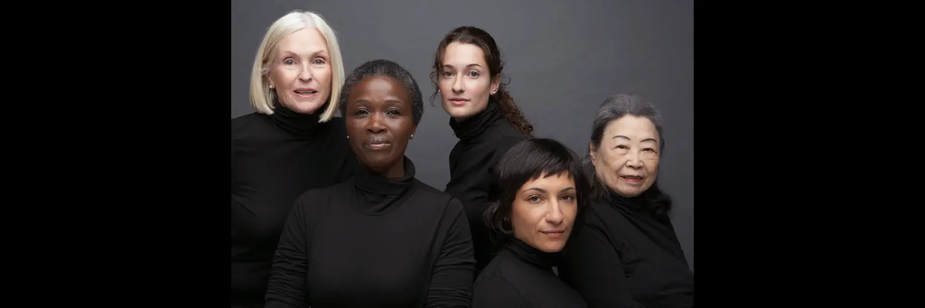

**Introduction to Race Report Section:**

In this section, I examine the racial distribution of individuals at the time of their arrest. By delving into the status of race among those who encountered the legal system, I aim to illuminate how different racial groups are represented within the context of legal interactions. This analysis provides insights into the diversity of the incarcerated population and prompts discussions about the potential implications of racial disparities within the criminal justice system.

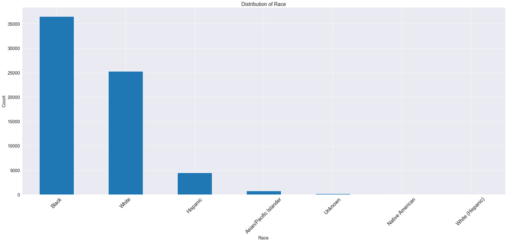

```python
race= jail_record.race.value_counts()
plt.figure(figsize=(25,12))
race.plot(kind='bar')

plt.xlabel('Race',fontsize=16)
plt.ylabel('Count',fontsize=16)
plt.title('Distribution of Race',fontsize=18)

plt.xticks(fontsize=18,rotation=45)# Rotate x-labels for better visibility
plt.yticks(fontsize=16)
plt.tight_layout()
plt.show()
```

### Observations

- **Dominant Racial Groups:** The data indicates that the most frequent racial category among individuals in the dataset is "Black," followed by "White." This suggests that these two racial groups constitute a significant proportion of the incarcerated population.
- **Diverse Representation:** The dataset encompasses a variety of racial categories, including "Black," "White," "Hispanic," "Asian/Pacific Islander," "Native American," and "Unknown."
- **Overrepresentation of Black Individuals:** The higher count of "Black" individuals among the incarcerated population might indicate an overrepresentation compared to their proportion in the general population.

### Questions

- **What factors contribute to the higher representation of the Black race in the jail population?**

The overrepresentation of the "Black" race in the Illinois state jail could be influenced by a combination of societal, systemic, and historical factors. It's important to approach this topic with sensitivity and acknowledge the complexity of the issue. Here are some factors that might contribute to the observed trend:

> 1. **Racial Disparities in Criminal Justice:** There's a well-documented history of racial disparities within the criminal justice system, often referred to as racial profiling and unequal treatment. This can lead to a higher likelihood of arrest, conviction, and incarceration for Black individuals.
> 2. **Systemic Bias:** Discriminatory practices and systemic biases in law enforcement, prosecution, and sentencing can disproportionately affect Black individuals, leading to their overrepresentation in the criminal justice system.
> 3. **Socioeconomic Factors:** Economic disparities can lead to limited access to quality education, employment opportunities, and social support, increasing the likelihood of engaging in activities that could result in legal involvement.
> 4. **Community Policing:** Over-policing in certain neighborhoods can lead to a higher number of arrests within those communities, impacting the overall racial distribution of incarcerated individuals.
> 5. **Sentencing Disparities:** Sentencing practices can vary based on race, leading to longer sentences for certain racial groups, which can contribute to an overrepresentation in the prison population.
> 6. **War on Drugs:** Historical policies, such as the "War on Drugs," have disproportionately targeted Black communities, resulting in higher arrest rates for drug-related offenses.
> 7. **Implicit Bias:** Unconscious biases held by individuals within the criminal justice system can affect decision-making, potentially leading to harsher treatment for certain racial groups.
> 8. **Intersecting Factors:** The intersection of race with other variables like socioeconomic status, education, and employment can compound the likelihood of legal interactions.

Addressing the overrepresentation of the "Black" race in the incarcerated population requires comprehensive criminal justice reform, policy changes, and efforts to dismantle systemic biases. It also necessitates understanding and addressing the broader societal issues that contribute to these disparities, including economic inequality, education inequities, and social injustices.

- **Why is there a significant drop in the number of individuals from the "White" race to the category of "Other" races within the Illinois State prison population data?**

The sharp decline in the number of incarcerated individuals from the "White" racial category to the "Other" racial categories could be attributed to a combination of factors related to demographics, representation, and the specific context of the Illinois state jail system. Here are some possible explanations:

> 1. **Demographic Composition:** The racial demographics of the larger population might play a role. If the population within the state has a higher proportion of individuals from the "White" racial category, it could lead to a larger number of White individuals interacting with the criminal justice system.
> 2. **Racial Disparities:** The existence of racial disparities within the criminal justice system might affect arrest rates and legal interactions differently for various racial groups. Factors like law enforcement practices, implicit biases, and socioeconomic conditions can contribute to these disparities.
> 3. **Legal System Dynamics:** Factors within the legal system, such as sentencing practices, plea bargains, and conviction rates, could influence the representation of different racial groups within the incarcerated population.
> 4. **Crime Patterns:** The types of crimes committed might vary among racial groups, affecting the likelihood of arrest and incarceration. Racial disparities can also impact how certain crimes are policed and prosecuted.
> 5. **Population Size:** Smaller population sizes in the "Other" racial categories compared to "White" might naturally result in fewer individuals from those groups being incarcerated.
> 6. **Reporting and Data Collection:** Differences in how racial data is reported, collected, and categorized can influence how individuals are counted within each racial category.
> 7. **Intersectionality:** Other variables such as age, socioeconomic status, and geography might intersect with race, leading to varying levels of legal interactions for different racial groups.
> 8. **Data Limitations:** The "Other" category might include diverse racial backgrounds, making it challenging to draw specific conclusions about individual racial groups within that category.

The sharp decline underscores the complex interplay of various factors shaping the racial distribution of incarcerated individuals. It's crucial to approach this issue with a nuanced understanding of historical, societal, and systemic influences that contribute to the observed patterns. Comprehensive efforts to address racial disparities within the criminal justice system require systemic reforms, policy changes, and a commitment to fairness and equity.

## SEX

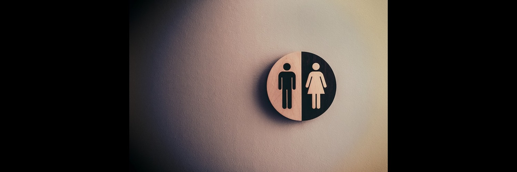

**Introduction to Sex Analysis:**

This section delves into the sex distribution among individuals within the Illinois prison system. Examining the representation of males and females provides insights into gender dynamics within the incarcerated population. By analyzing this data, I aim to understand any disparities, trends, and potential implications that sex may have on legal interactions and the broader context of the criminal justice system.

```python
sex= jail_record.sex.value_counts()
```

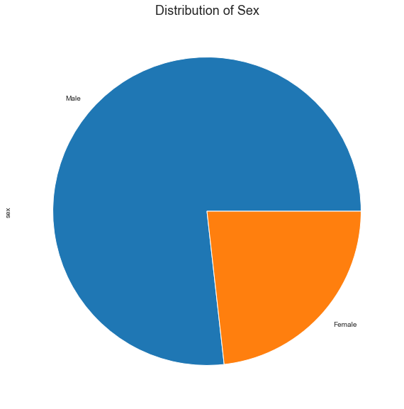

```python
plt.figure(figsize=(10,10))
sex.plot(kind='pie')

plt.title('Distribution of Sex',fontsize=18)

plt.xticks(fontsize=18)
plt.yticks(fontsize=16)

plt.show()
```

### Observations

- **Male Dominance:** The data indicates that the majority of individuals in the dataset are classified as "Male." This suggests that males constitute a larger proportion of the incarcerated population in Illinois prisons.
- **Female Representation:** While the count of females is lower compared to males, there is still a notable representation of "Female" individuals within the incarcerated population.
- **Gender Disparities**: The higher count of "Male" individuals may highlight gender disparities within the criminal justice system, potentially reflecting broader societal dynamics and law enforcement practices.

### Question

- **What are the factors that contribute to the higher representation of males in the prison population?**

The dominance of males in the prison population can be attributed to a complex interplay of social, biological, and systemic factors. While the reasons are multifaceted and can vary across different contexts, here are some key contributing factors to the overrepresentation of males in prisons:

> 1. **Gendered Criminal Behavior:** Social norms and gender roles can influence the types of crimes individuals are more likely to commit. Males might be more engaged in certain types of criminal behavior due to a combination of societal expectations, peer influences, and risk-taking behaviors.
> 2. **Law Enforcement Practices:** Law enforcement practices and biases can lead to the over-policing of certain communities and demographic groups, including males. This can result in a higher likelihood of arrests and interactions with the criminal justice system.
> 3. **Socioeconomic Factors:** Economic disparities can contribute to criminal involvement. Males in disadvantaged socioeconomic situations might resort to criminal activities as a means of economic survival.
> 4. **Cultural Influences:** Societal norms that encourage displays of masculinity, toughness, and aggression might contribute to males engaging in behavior that leads to legal interactions.
> 5. **Sentencing Disparities:** Sentencing practices might result in longer sentences for males due to perceptions of increased dangerousness or other biases, leading to a higher representation in the incarcerated population.
> 6. **Historical Context:** Historical policies and practices, including those related to drug enforcement and sentencing, have disproportionately affected males, particularly those from marginalized communities.
> 7. **Biological Factors:** While biological differences alone do not explain the disparity, some argue that certain hormones might influence behavior. However, societal and environmental factors have more significant impacts.
> 8. **Social Support Networks:** Strong social support networks can act as protective factors against criminal involvement. Females might have stronger social networks that deter them from engaging in criminal activities.

Addressing the dominance of males in prison requires a holistic approach that involves criminal justice reform, addressing socioeconomic inequalities, challenging gender stereotypes, and promoting education and employment opportunities. Efforts to understand and rectify the systemic factors that contribute to these disparities are crucial for a fair and equitable criminal justice system.

## Education Status

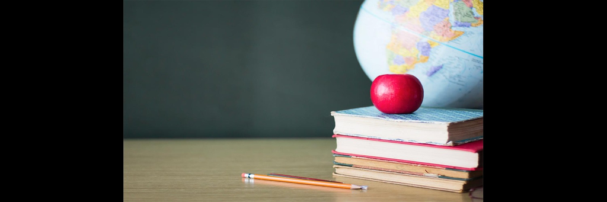

**Introduction to Education Status Analysis:**

In the analysis of education status within this report, I examine the educational backgrounds of individuals at the time they were arrested. This section sheds light on the level of education attained by incarcerated individuals, providing insights into how educational experiences intersect with legal interactions. By understanding the education status of those within the criminal justice system, I aim to uncover potential links between education and legal involvement, highlighting the significance of educational interventions and opportunities in shaping paths toward rehabilitation and reintegration.

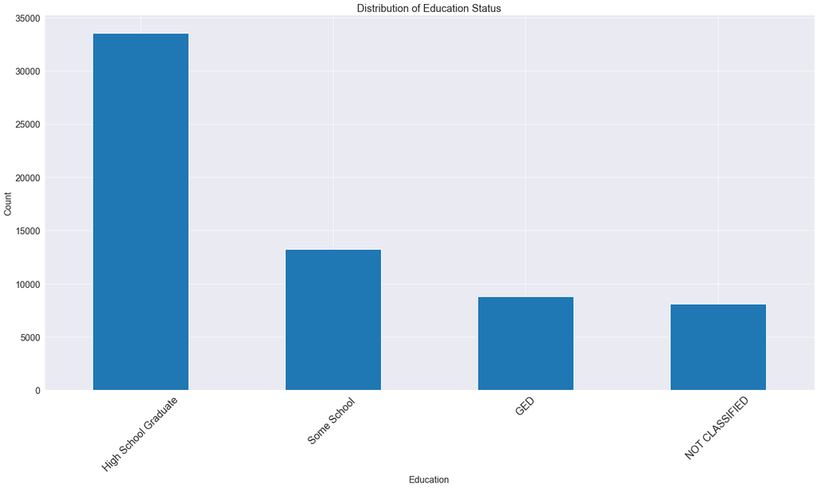

```python
education= jail_record.education_status.value_counts()
plt.figure(figsize=(20,12))
education.plot(kind='bar')

plt.xlabel('Education',fontsize=16)
plt.ylabel('Count',fontsize=16)
plt.title('Distribution of Education Status',fontsize=18)

plt.xticks(fontsize=18,rotation=45)# Rotate x-labels for better visibility
plt.yticks(fontsize=16)
plt.tight_layout()
plt.show()
```

### Observations

- **Education Status and High School Attainment:** Looking at the data, a lot of inmates finished high school. There's also a group that went to school but didn't finish high school. This suggests that not completing high school might be connected to being in jail. Having educational programs in jail could help because education might keep people from doing things that lead to jail.
- **Education Diversity:** The dataset reflects a diversity of educational backgrounds among the incarcerated population, ranging from high school graduates to individuals with various levels of schooling.
- **High School Graduates:** The most frequent education status among individuals in the dataset is "High School Graduate." This suggests that a substantial proportion of incarcerated individuals have completed their high school education.
- **Varied Educational Attainment:** Beyond high school graduates, the presence of "Some School," "GED" (General Educational Development), and "NOT CLASSIFIED" statuses indicates that individuals with different levels of educational attainment are represented in the incarcerated population.

### Question

- **How does the education status of prisoners show the connection between their level of schooling and getting involved with the law?**

> This data reminds us that helping people with their education can help prevent crime and help them do better after being in jail.

## Recommendations

- **Education Programs:** Establish comprehensive educational programs within correctional facilities to address educational gaps and equip inmates with skills that can aid reintegration upon release.
- **Youth Interventions:** Develop targeted interventions for young adults, especially those in their early twenties, to address risk-taking behaviors and provide alternatives to criminal activities.
- **Racial Equity Initiatives:** Implement reforms aimed at addressing racial disparities within the criminal justice system, including unbiased policing, fair sentencing practices, and promoting community-based alternatives.
- **Vocational Training:** Offer vocational training programs to provide inmates with employable skills, reducing the risk of recidivism by facilitating post-release employment.
- **Support for Marginalized Groups:** Create tailored support systems for marginalized groups, such as females and individuals with incomplete education, addressing their unique needs and promoting successful reentry into society.

Implementing these recommendations can contribute to a fairer criminal justice system, reduced recidivism rates, and improved outcomes for both incarcerated individuals and society as a whole.